# Analise RNASeq a celulas humanas TNBC

### 3.1.4 Transformação dos dados e visualização

Os dados transformados devem corresponder à *approximated variance stabilized* e também incluir a correcção dos factores de tamanho/normalização.

Para testar a qualidade dos dados transformados procedeu-se ao clustering e visualização dos dados. Com isto pretende-se também identificar os genes expressos de maneira diferencial, em particular, amostras cuja condição tenha tido influência no resultados gerados.

```r
#VST: varianceStabilizingTransformation
vsd <- varianceStabilizingTransformation(dds, blind = FALSE)

#comparar antes e apos normalizar
head(counts(dds), 3)
```

```
##                 SR05 SR06 SR07 SR08 SR09 SR10
## ENSG00000002834   32   36   48   54   55   29
## ENSG00000002919    2    2    5    5    3    4
## ENSG00000004142   42   51   48   25   24   23
```

```r
head(assay(vsd), 3)
```

```
##                     SR05     SR06     SR07     SR08     SR09     SR10
## ENSG00000002834 6.930884 6.878105 7.015276 7.200139 7.120595 7.052745
## ENSG00000002919 6.131267 6.102403 6.239800 6.279088 6.161040 6.311994
## ENSG00000004142 7.079033 7.062514 7.015276 6.788002 6.706309 6.927871
```

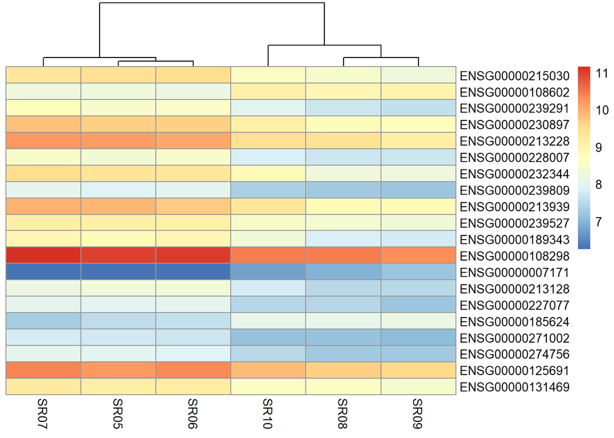

```r
#contruir Heatmap com clustering
select <- rownames(head(resOrdered, 20)) #top 20 apenas
vsd.counts <- assay(vsd)[select,]
df <- as.data.frame(colData(dds)[, c("condition")])

pheatmap(vsd.counts, cluster_rows = FALSE)
```

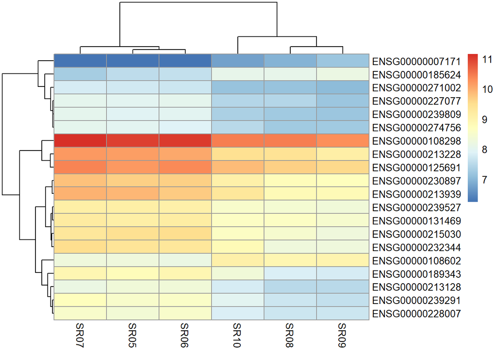

```r
pheatmap(vsd.counts)
```

```r
#heatmap mostra a diferenca clara entre a expressao genetica entre reads de diferentes fatores
```

### 3.1.5 Cálculo distância entre amostras

Heatmap gerado através da distância entre samples é outro dos usos para os dados tranformados, onde são calculadas as distâncias dos dados da matriz transposta.

```r
sampleDists <- dist(t(assay(vsd)))
sampleDistMatrix <- as.matrix(sampleDists)
rownames(sampleDistMatrix) <- dds$condition
colnames(sampleDistMatrix) <- NULL

head(sampleDistMatrix)
```

```
##              [,1]     [,2]     [,3]     [,4]     [,5]     [,6]
## bulk     0.000000 4.334639 4.549279 7.542813 8.118222 7.160337
## bulk     4.334639 0.000000 4.024644 7.562850 8.127895 7.094693
## bulk     4.549279 4.024644 0.000000 7.890002 8.512811 7.230328
## spheroid 7.542813 7.562850 7.890002 0.000000 4.300727 5.516622
## spheroid 8.118222 8.127895 8.512811 4.300727 0.000000 6.026423
## spheroid 7.160337 7.094693 7.230328 5.516622 6.026423 0.000000
```

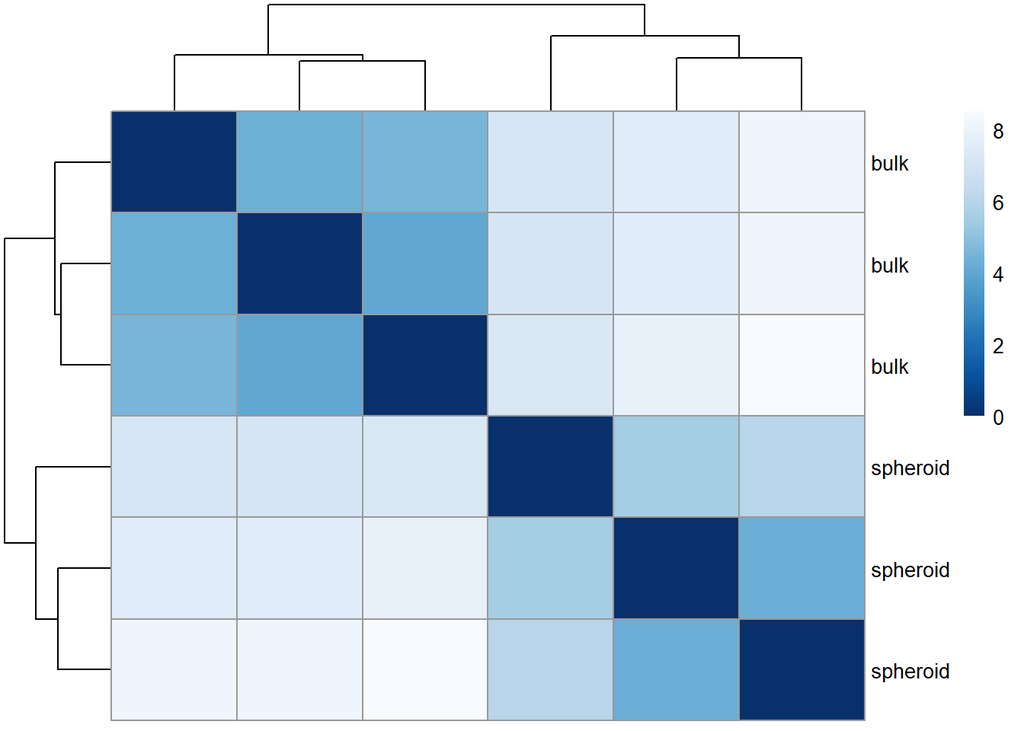

```r
colors <- colorRampPalette(rev(brewer.pal(9, "Blues")))(255)
#Heatmap com distancias
pheatmap(
  sampleDistMatrix,
  clustering_distance_rows = sampleDists,
  clustering_distance_cols = sampleDists,
  col = colors
)
```

**Heatmap da matriz de distância** dá nos uma visão geral das semelhanças e diferenças entre as amostras. Que mais uma vez confirma o agrupamento das samples sob a condição *bulk* e *spheroid*.

### 3.1.6 Principal Component Analysis (PCA)

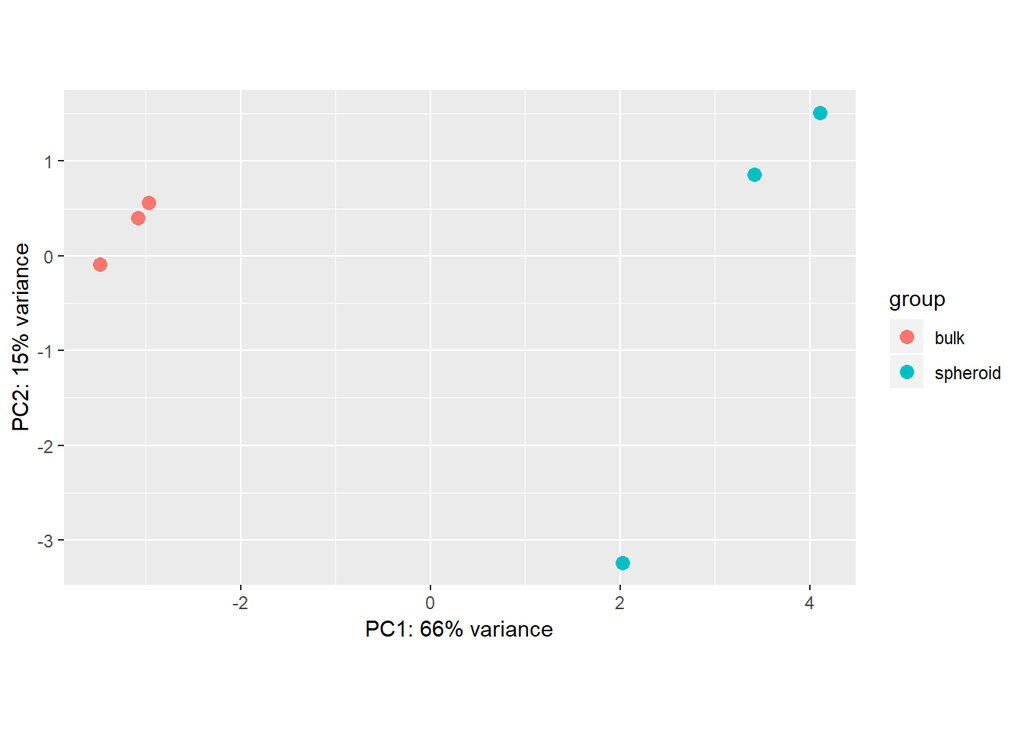

```r
plotPCA(vsd, intgroup = c("condition"))
```

## 3.2 Análise RNASeq a celulas humanas TNBC alinhadas ao cromossoma 13

### 3.2.1 Carregar dados e respetivo processamento:

```r
#Load de tabela de contagens
sr13 <- read.table("ch13finalreadcount.tab", h = T, row.names = 1)
tail(sr13) # fragmentos do ficheiro que n?o s?o necess?rios para a an?lise
```

```
##                           SR05    SR06    SR07    SR08    SR09    SR10
## ENSG00000286272              0       0       0       0       0       0
## __no_feature              5339    6723    6447    5270    6622    3326
## __ambiguous                586     752     673     507     535     328
## __too_low_aQual           6295    7845    7440    6634    8385    4275
## __not_aligned          3373953 4125118 4214933 3694022 4343302 2429182
## __alignment_not_unique       0       0       0       0       0       0
```

```r
#remover fragmentos
sr13 <- sr13[1:(nrow(sr13) - 5), ]
head(sr13)
```

```
##                 SR05 SR06 SR07 SR08 SR09 SR10
## ENSG00000000003    0    0    0    0    0    0
## ENSG00000000005    0    0    0    0    0    0
## ENSG00000000419    0    0    0    0    0    0
## ENSG00000000457    0    0    0    0    0    0
## ENSG00000000460    0    0    0    0    0    0
## ENSG00000000938    0    0    0    0    0    0
```

```r
#filtrar genes que não são expressos
sr13 <- sr13[rowSums(sr13) > 1,]
head(sr13)
```

```
##                 SR05 SR06 SR07 SR08 SR09 SR10
## ENSG00000005810   70   83   66  110  142   77
## ENSG00000005812   23   16   16   35   32   23
## ENSG00000023516   13   11   12   10   12   12
## ENSG00000027001    1    1    3    1    5    2
## ENSG00000032742    2    4    2    4    4    1
## ENSG00000065150  232  337  304  145  191  140
```

```r
dim(sr13) #dimensões após aplicar filtro
```

```
## [1] 408   6
```

```r
condition <- factor(c("bulk", "bulk", "bulk", "spheroid", "spheroid", "spheroid"))
cd <- data.frame(c("bulk", "bulk", "bulk", "spheroid", "spheroid", "spheroid"))
colnames(cd)[1] = "condition"
rownames(cd) = colnames(sr13)
```

### 3.2.2 Teste de expressão diferencial

```r
dds <- DESeqDataSetFromMatrix(countData = sr13,
                              colData = cd,
                              design = ~ condition)
dds <- DESeq(dds)
res <- results(dds)
res
```

```
## log2 fold change (MLE): condition spheroid vs bulk
## Wald test p-value: condition spheroid vs bulk
## DataFrame with 408 rows and 6 columns
##                          baseMean    log2FoldChange             lfcSE
##                         <numeric>         <numeric>         <numeric>
## ENSG00000005810   92.033945313558  1.04876166001627 0.231451637964913
## ENSG00000005812  24.9503562670835  1.17018718793014 0.421306196751523
## ENSG00000023516  11.6825982668754 0.414496495878619 0.579861251117617
## ENSG00000027001  2.13205720126245  1.16188791669094  1.36388589915652
## ENSG00000032742  2.71421720537477 0.611166041880951  1.17842654160864
## ...                           ...               ...               ...
## ENSG00000279231  3.51394018245378 0.697206637455633  1.10610460180274
## ENSG00000279730  179.296048961349 0.265699097564278  0.16965939053995
## ENSG00000280060 0.835181538133973 -1.70112193619121  2.19730863180487
## ENSG00000281106 0.490723452445526  1.34744886652959  3.01886673017722
## ENSG00000284196 0.305978028547689 0.498129961343002  3.58344371058903
##                               stat               pvalue
##                          <numeric>            <numeric>
## ENSG00000005810   4.53123455611601 5.86399859836563e-06
## ENSG00000005812   2.77752189963703   0.0054775148776107
## ENSG00000023516  0.714820131677577    0.474720193818357
## ENSG00000027001  0.851895248282502    0.394272234399286
## ENSG00000032742   0.51862888377129    0.604019563033958
## ...                            ...                  ...
## ENSG00000279231  0.630326134001537     0.52848122778081
## ENSG00000279730   1.56607362975121    0.117331380776978
## ENSG00000280060 -0.774184341502318    0.438821786738902
## ENSG00000281106  0.446342613623916     0.65534977884271
## ENSG00000284196  0.139008730588131    0.889443250021743
##                                 padj
##                            <numeric>
## ENSG00000005810 0.000102619975471399
## ENSG00000005812   0.0294943108794422
## ENSG00000023516    0.677224820546869
## ENSG00000027001                   NA
## ENSG00000032742                   NA
## ...                              ...
## ENSG00000279231                   NA
## ENSG00000279730     0.27076472486995
## ENSG00000280060                   NA
## ENSG00000281106                   NA
## ENSG00000284196                   NA
```

```r
mcols(res, use.names = TRUE) #metadados para legenda
```

```
## DataFrame with 6 rows and 2 columns
##                        type
##                 <character>
## baseMean       intermediate
## log2FoldChange      results
## lfcSE               results
## stat                results
## pvalue              results
## padj                results
##                                                       description
##                                                       <character>
## baseMean                mean of normalized counts for all samples
## log2FoldChange log2 fold change (MLE): condition spheroid vs bulk
## lfcSE                  standard error: condition spheroid vs bulk
## stat                   Wald statistic: condition spheroid vs bulk
## pvalue              Wald test p-value: condition spheroid vs bulk
## padj                                         BH adjusted p-values
```

```r
resOrdered <- res[order(res$padj),]
summary(res)
```

```
##
## out of 408 with nonzero total read count
## adjusted p-value < 0.1
## LFC > 0 (up)       : 22, 5.4%
## LFC < 0 (down)     : 34, 8.3%
## outliers [1]       : 0, 0%
## low counts [2]     : 198, 49%
## (mean count < 8)
## [1] see 'cooksCutoff' argument of ?results
## [2] see 'independentFiltering' argument of ?results
```

```r
sum(res$padj < 0.1, na.rm = TRUE)
```

```
## [1] 56
```

Ao ordernar os genes, de acordo com o atributo padj, pode-se observar que os genes com maior relevância são ENSG00000102804, ENSG00000180172, ENSG00000234031, ENSG00000102531, ENSG00000151846, ENSG00000136156. Ao considerar uma fração de falsos positivos de 10%, podemos considerar os genes com valor ajustado de p inferior a 0.1 como significativos(Verificamos que existem 56 genes que cumprem esta condição).

### 3.2.3 Exploração dos resultados

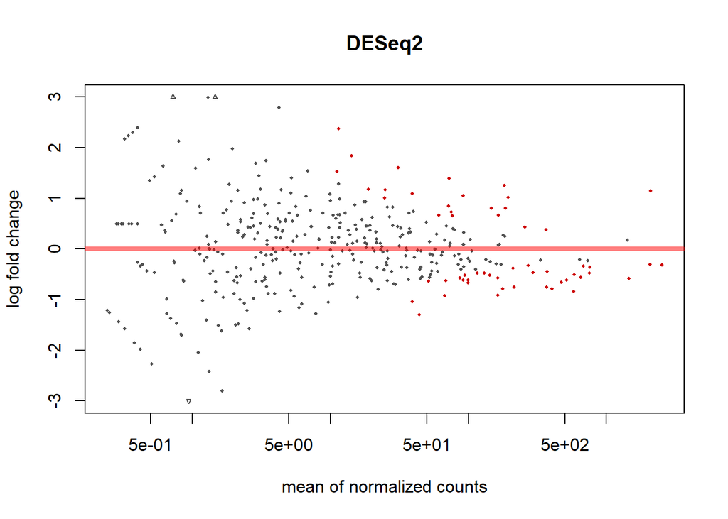

```r
#plot MA
DESeq2::plotMA(res, main = "DESeq2", ylim = c(-3, 3))
```

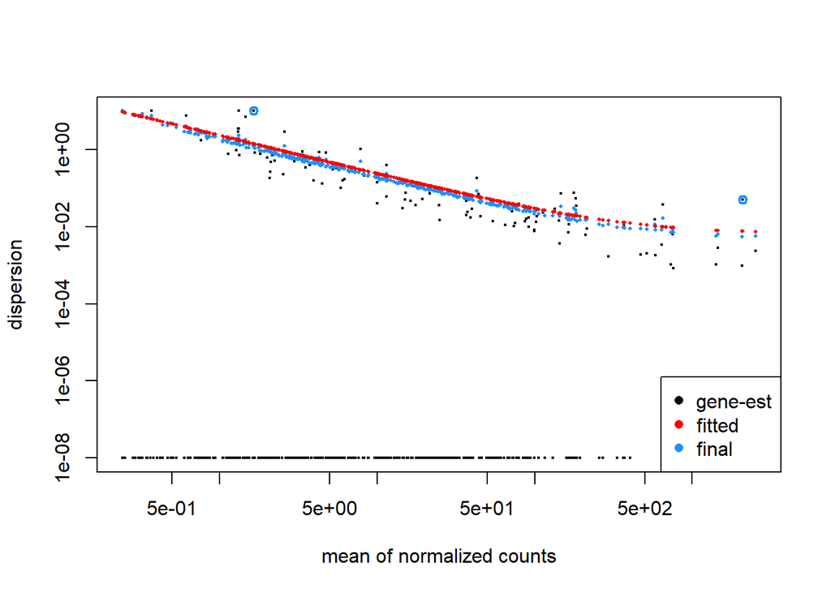

```r
#Dispersion plot
plotDispEsts(dds)
```

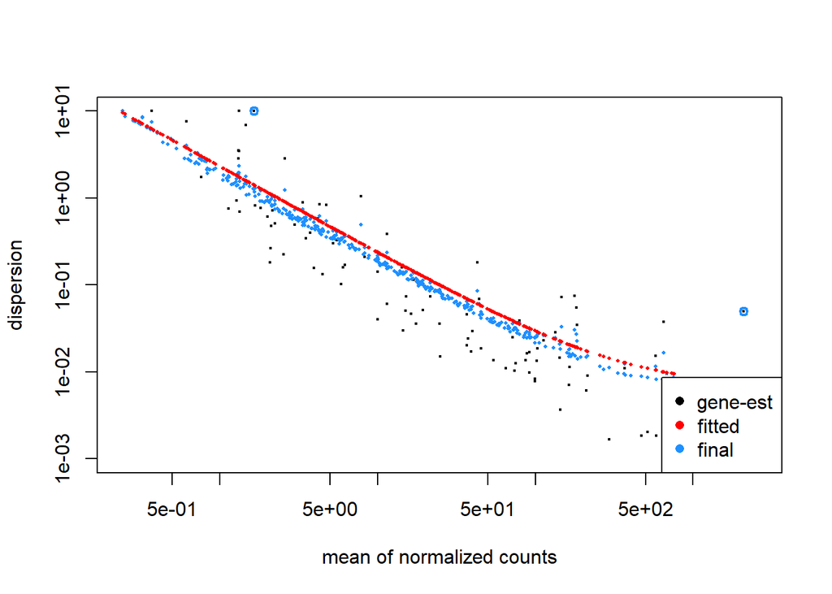

```r
plotDispEsts(dds, ylim = c(1e-3, 1e1))
```